# Analiza decyzji kredytowej z użyciem sieci Bayesowskiej

Bartosz Kawalec, Anna Oleszko

2026-05-25

# 1 Wprowadzenie

Celem projektu jest zbudowanie i zinterpretowanie **dyskretnej sieci Bayesowskiej** wspierającej analizę decyzji kredytowej. Główne pytanie analityczne brzmi:

> Jak zmienia się warunkowe prawdopodobieństwo pozytywnej lub negatywnej decyzji kredytowej po uwzględnieniu informacji o profilu klienta, jego historii kredytowej i parametrach wniosku?

Zmienną wynikową jest `loan_status`, przyjmująca wartości `Pozytywna` oraz `Odrzucona`. Analiza nie ma na celu zbudowania produkcyjnego systemu scoringowego ani wykazania zależności przyczynowo-skutkowych. Jej celem jest poznanie struktury zależności probabilistycznych w danych oraz demonstracja wnioskowania scenariuszowego.

Sieć Bayesowska opisuje wspólny rozkład prawdopodobieństwa wielu zmiennych za pomocą grafu skierowanego i warunkowych rozkładów prawdopodobieństwa. Dzięki temu może służyć zarówno do opisu struktury zależności, jak i do odpowiadania na pytania typu „co zmienia się po zaobserwowaniu określonej informacji o kliencie?”.

# 2 Cel i zakres projektu

Projekt obejmuje:

1. kontrolę jakości i eksplorację zbioru danych,
2. identyfikację oraz ograniczenie redundancji między zmiennymi,
3. przygotowanie danych do dyskretnej sieci Bayesowskiej,
4. porównanie trzech algorytmów uczenia struktury: Hill-Climbing, Tabu Search oraz MMHC,
5. ocenę struktur za pomocą BIC,
6. uzupełniającą walidację krzyżową dla zmiennej `loan_status`,
7. ocenę stabilności łuków metodą bootstrap,
8. uczenie parametrów wybranej sieci,
9. wnioskowanie prognostyczne i diagnostyczne,
10. interpretację biznesową oraz omówienie ograniczeń.

# 3 Dane

## 3.1 Źródło danych

Do analizy wykorzystano zbiór `Loan_approval_data_2025.csv`, zawierający 50 000 obserwacji klientów i wniosków kredytowych. Zbiór pochodzi z publicznego repozytorium Kaggle **Realistic Loan Approval Dataset: US and Canada**. Projekt wykorzystuje dane jako materiał analityczny; wyniki odnoszą się do tego konkretnego zbioru i nie powinny być automatycznie generalizowane na rzeczywisty portfel dowolnego banku.

## 3.2 Kontrola jakości danych

50000

obserwacji

20

zmiennych w pliku źródłowym

0

braków danych

Kontrola jakości danych wejściowych

| Miara | Wartosc |
| --- | --- |
| Liczba obserwacji | 50000 |
| Liczba kolumn | 20 |
| Braki danych | 0 |
| Duplikaty customer_id | 0 |
| Duplikaty całych wierszy | 0 |

## 3.3 Charakter i słownik zmiennych

Słownik zmiennych w danych źródłowych

| Zmienna | Opis |
| --- | --- |
| age | wiek klienta |
| occupation_status | status zawodowy klienta |
| years_employed | liczba lat zatrudnienia |
| annual_income | roczny dochód klienta |
| credit_score | ocena kredytowa klienta |
| credit_history_years | długość historii kredytowej |
| savings_assets | wartość oszczędności i aktywów |
| current_debt | aktualne zadłużenie klienta |
| defaults_on_file | informacja o wcześniejszych niespłaconych zobowiązaniach |
| delinquencies_last_2yrs | liczba opóźnień w spłacie w ostatnich dwóch latach |
| derogatory_marks | liczba negatywnych wpisów w historii kredytowej |
| loan_amount | kwota wnioskowanej pożyczki |
| interest_rate | oprocentowanie pożyczki |
| loan_intent | cel pożyczki |
| product_type | typ produktu kredytowego |
| debt_to_income_ratio | relacja aktualnego zadłużenia do dochodu |
| loan_to_income_ratio | relacja kwoty pożyczki do dochodu |
| payment_to_income_ratio | relacja płatności do dochodu |
| loan_status | decyzja kredytowa — zmienna wynikowa |

# 4 Wstępna analiza danych

## 4.1 Rozkład decyzji kredytowej

Rozkład zmiennej wynikowej loan_status

| Decyzja | Liczba obserwacji | Udział |
| --- | --- | --- |
| Odrzucona | 22477 | 0.4495 |
| Pozytywna | 27523 | 0.5505 |

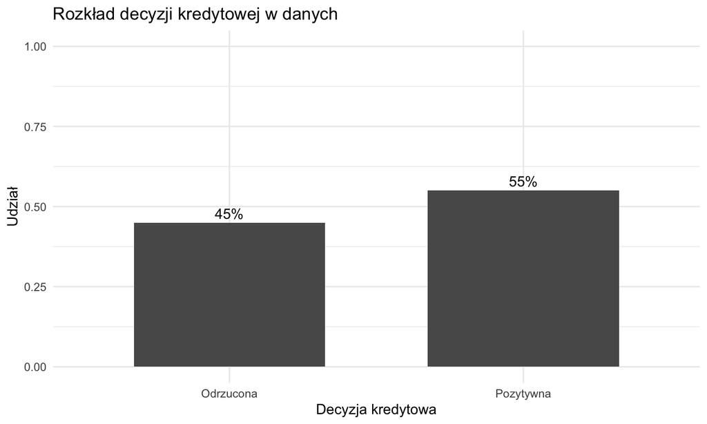

## 4.2 Szczególna zależność: `defaults_on_file`

Przed uczeniem modelu warto sprawdzić proste zależności, które mogą silnie wpływać na wynik. Poniższa tabela pokazuje relację między wcześniejszym defaultem a decyzją kredytową.

Decyzja kredytowa a defaults_on_file

| Default w historii | Decyzja | Liczba | Udział w grupie |
| --- | --- | --- | --- |
| Nie | Odrzucona | 19803 | 0.4184 |
| Nie | Pozytywna | 27523 | 0.5816 |
| Tak | Odrzucona | 2674 | 1.0000 |

W analizowanym zbiorze znajduje się **2674** obserwacji z `defaults_on_file = 1`. Liczba pozytywnych decyzji w tej grupie wynosi **0**. Jest to właściwość tego zbioru danych, a nie uniwersalna reguła kredytowa; należy ją uwzględnić przy interpretacji struktury sieci i wyników wnioskowania.

# 5 Redundancja i wybór cech do modelu

W danych występują zmienne pochodne, które są prawie deterministycznie związane z innymi kolumnami. W sieci Bayesowskiej takie relacje mogą powodować, że algorytm uczy się przede wszystkim wzorów matematycznych użytych do konstrukcji wskaźników zamiast bardziej interesujących zależności między cechami.

Kontrola prawie deterministycznych zależności między zmiennymi

| Relacja | Maksymalny_blad_bezwzgledny |
| --- | --- |
| debt_to_income_ratio ≈ current_debt / annual_income | 0.000500 |
| loan_to_income_ratio ≈ loan_amount / annual_income | 0.000500 |
| payment_to_income_ratio ≈ loan_to_income_ratio / 3 | 0.000667 |

W modelu zachowano `debt_to_income_ratio`, ponieważ jest czytelną biznesowo miarą obciążenia dochodu zadłużeniem. Jednocześnie usunięto `current_debt`, aby nie przechowywać jednocześnie wskaźnika i jego obu składników. Usunięto również `loan_to_income_ratio` oraz `payment_to_income_ratio`; pierwszy jest bezpośrednio wyliczany z `loan_amount` i `annual_income`, a drugi jest niemal liniową transformacją `loan_to_income_ratio`.

Ta decyzja nie oznacza, że usunięte zmienne są biznesowo nieistotne. Jej celem jest ograniczenie redundancji i ułatwienie interpretacji struktury sieci.

# 6 Przygotowanie danych

```r
dane_bn <- dane %>%
  select(
    -customer_id,
    -current_debt,
    -loan_to_income_ratio,
    -payment_to_income_ratio
  ) %>%
  mutate(
    loan_status = factor(
      loan_status,
      levels = c(0, 1),
      labels = c("Odrzucona", "Pozytywna")
    ),
    defaults_on_file = factor(
      defaults_on_file,
      levels = c(0, 1),
      labels = c("Nie", "Tak")
    ),
    occupation_status = as.factor(occupation_status),
    product_type = as.factor(product_type),
    loan_intent = as.factor(loan_intent)
  )
```

## 6.1 Dyskretyzacja zmiennych liczbowych

W projekcie zastosowano **dyskretną** sieć Bayesowską, dlatego zmienne ciągłe i liczbowe zostały przekształcone do poziomów jakościowych. Dla zmiennych o większej liczbie różnych wartości zastosowano podział kwantylowy na trzy grupy (`niski`, `sredni`, `wysoki`). Dla zmiennych o niewielkiej liczbie unikalnych wartości zachowano wartości obserwowane jako osobne poziomy faktora.

```r
zmienne_numeryczne <- c(
  "age",
  "years_employed",
  "annual_income",
  "credit_score",
  "credit_history_years",
  "savings_assets",
  "delinquencies_last_2yrs",
  "derogatory_marks",
  "loan_amount",
  "interest_rate",
  "debt_to_income_ratio"
)

dyskretyzuj <- function(x, prog_malo_wartosci = 10) {
  x_bez_na <- x[!is.na(x)]
  liczba_unikalnych <- length(unique(x_bez_na))

  if (liczba_unikalnych <= prog_malo_wartosci) {
    return(as.factor(x))
  }

  granice <- unique(as.numeric(quantile(
    x,
    probs = c(0, 1/3, 2/3, 1),
    na.rm = TRUE,
    type = 7
  )))

  liczba_przedzialow <- length(granice) - 1

  if (liczba_przedzialow < 2) {
    return(as.factor(x))
  }

  etykiety <- switch(
    as.character(liczba_przedzialow),
    "2" = c("niski", "wysoki"),
    "3" = c("niski", "sredni", "wysoki"),
    paste0("poziom_", seq_len(liczba_przedzialow))
  )

  cut(
    x,
    breaks = granice,
    include.lowest = TRUE,
    labels = etykiety,
    ordered_result = TRUE
  )
}

dane_bn <- dane_bn %>%
  mutate(across(all_of(zmienne_numeryczne), dyskretyzuj))

dane_bn[] <- lapply(dane_bn, as.factor)
```

Liczba i nazwy poziomów zmiennych po przygotowaniu danych

| Zmienna | Liczba_poziomow | Poziomy |
| --- | --- | --- |
| age | 3 | niski, sredni, wysoki |
| occupation_status | 3 | Employed, Self-Employed, Student |
| years_employed | 3 | niski, sredni, wysoki |
| annual_income | 3 | niski, sredni, wysoki |
| credit_score | 3 | niski, sredni, wysoki |
| credit_history_years | 3 | niski, sredni, wysoki |
| savings_assets | 3 | niski, sredni, wysoki |
| defaults_on_file | 2 | Nie, Tak |
| delinquencies_last_2yrs | 10 | 0, 1, 2, 3, 4, 5, 6, 7, 8, 9 |
| derogatory_marks | 5 | 0, 1, 2, 3, 4 |
| product_type | 3 | Credit Card, Line of Credit, Personal Loan |
| loan_intent | 6 | Business, Debt Consolidation, Education, Home Improvement, Medical, Personal |
| loan_amount | 3 | niski, sredni, wysoki |
| interest_rate | 3 | niski, sredni, wysoki |
| debt_to_income_ratio | 3 | niski, sredni, wysoki |
| loan_status | 2 | Odrzucona, Pozytywna |

# 7 Uczenie struktury sieci Bayesowskiej

## 7.1 Założenia strukturalne

`loan_status` jest w projekcie traktowana jako zmienna wynikowa. Zastosowano więc blacklistę blokującą łuki **wychodzące** z `loan_status`. Jest to założenie modelowe służące interpretacji i wnioskowaniu prognostycznemu — nie oznacza ono, że kierunki łuków dowodzą przyczynowości.

Dla modeli score-based ograniczono maksymalną liczbę rodziców pojedynczego węzła do 3. To samo ograniczenie przekazano do fazy maksymalizacji MMHC, aby porównanie metod było bardziej spójne.

```r
blacklist <- data.frame(
  from = "loan_status",
  to = setdiff(names(dane_bn), "loan_status")
)

set.seed(123)

model_hc <- bnlearn::hc(
  dane_bn,
  score = "bic",
  blacklist = blacklist,
  maxp = 3
)

model_tabu <- bnlearn::tabu(
  dane_bn,
  score = "bic",
  blacklist = blacklist,
  maxp = 3
)

model_mmhc <- bnlearn::mmhc(
  dane_bn,
  blacklist = blacklist,
  maximize.args = list(
    score = "bic",
    maxp = 3
  )
)
```

# 8 Porównanie modeli

## 8.1 Kryterium BIC

BIC służy tu do porównania struktur wyuczonych na tym samym zbiorze danych. W implementacji `bnlearn` większa wartość score BIC oznacza korzystniejszy kompromis między dopasowaniem a złożonością modelu.

```r
score_hc <- bnlearn::score(model_hc, dane_bn, type = "bic")
score_tabu <- bnlearn::score(model_tabu, dane_bn, type = "bic")
score_mmhc <- bnlearn::score(model_mmhc, dane_bn, type = "bic")

porownanie_modeli <- data.frame(
  Model = c("Hill-Climbing", "Tabu Search", "MMHC"),
  BIC_surowe = c(score_hc, score_tabu, score_mmhc),
  stringsAsFactors = FALSE
)

porownanie_modeli$BIC <- round(porownanie_modeli$BIC_surowe, 2)

knitr::kable(
  porownanie_modeli[, c("Model", "BIC")],
  caption = "Porównanie struktur za pomocą BIC"
)
```

Porównanie struktur za pomocą BIC

| Model | BIC |
| --- | --- |
| Hill-Climbing | -671801.7 |
| Tabu Search | -671787.1 |
| MMHC | -679563.5 |

## 8.2 Uzupełniająca walidacja krzyżowa

BIC nie jest walidacją poza próbą. Dlatego dodatkowo wykonano 5-fold cross-validation, w której w każdym foldzie struktura jest uczona ponownie, a następnie oceniana jest klasyfikacja `loan_status`. Jako miarę podano błąd klasyfikacji oraz odpowiadającą mu trafność (`1 - błąd`).

Walidacja dotyczy przygotowanego już, zdyskretyzowanego zbioru. Nie jest to pełna walidacja produkcyjnego pipeline’u, ponieważ progi dyskretyzacji zostały ustalone przed podziałem na foldy.

```r
args_hc <- list(
  score = "bic",
  blacklist = blacklist,
  maxp = 3
)

args_tabu <- list(
  score = "bic",
  blacklist = blacklist,
  maxp = 3
)

args_mmhc <- list(
  blacklist = blacklist,
  maximize.args = list(
    score = "bic",
    maxp = 3
  )
)

set.seed(123)

cv_hc <- bnlearn::bn.cv(
  dane_bn,
  bn = "hc",
  loss = "pred",
  algorithm.args = args_hc,
  loss.args = list(
    target = "loan_status",
    predict = "parents"
  ),
  fit = "bayes",
  method = "k-fold",
  k = 5,
  runs = 1
)

cv_tabu <- bnlearn::bn.cv(
  dane_bn,
  bn = "tabu",
  loss = "pred",
  algorithm.args = args_tabu,
  loss.args = list(
    target = "loan_status",
    predict = "parents"
  ),
  fit = "bayes",
  method = "k-fold",
  k = 5,
  runs = 1
)

cv_mmhc <- bnlearn::bn.cv(
  dane_bn,
  bn = "mmhc",
  loss = "pred",
  algorithm.args = args_mmhc,
  loss.args = list(
    target = "loan_status",
    predict = "parents"
  ),
  fit = "bayes",
  method = "k-fold",
  k = 5,
  runs = 1
)

bledy_cv <- c(
  as.numeric(bnlearn::loss(cv_hc))[1],
  as.numeric(bnlearn::loss(cv_tabu))[1],
  as.numeric(bnlearn::loss(cv_mmhc))[1]
)

walidacja_modeli <- data.frame(
  Model = c("Hill-Climbing", "Tabu Search", "MMHC"),
  Blad_klasyfikacji_CV = bledy_cv,
  Trafnosc_CV = 1 - bledy_cv,
  stringsAsFactors = FALSE
)

baseline_accuracy <- max(prop.table(table(dane_bn$loan_status)))

knitr::kable(
  transform(
    walidacja_modeli,
    Blad_klasyfikacji_CV = round(Blad_klasyfikacji_CV, 4),
    Trafnosc_CV = round(Trafnosc_CV, 4)
  ),
  caption = "5-fold cross-validation dla loan_status"
)
```

5-fold cross-validation dla loan_status

| Model | Blad_klasyfikacji_CV | Trafnosc_CV |
| --- | --- | --- |
| Hill-Climbing | 0.2267 | 0.7733 |
| Tabu Search | 0.2267 | 0.7733 |
| MMHC | 0.2267 | 0.7733 |

Trafność prostego klasyfikatora większościowego wynosi 55%. Wyniki CV warto interpretować również względem tego punktu odniesienia.

## 8.3 Wybór algorytmu do dalszej analizy

Podstawowym kryterium wyboru pozostaje BIC, ponieważ celem projektu jest analiza struktury zależności, a nie wyłącznie klasyfikacja. Jeżeli kilka metod uzyskuje praktycznie identyczny najwyższy BIC, remis rozstrzygany jest niższym błędem klasyfikacji w cross-validation.

Do dalszej analizy wybrano model Tabu Search, ponieważ uzyskał najwyższą wartość BIC. Jego uzupełniająca trafność w 5-fold CV wyniosła 77.3%.

# 9 Stabilność struktury: bootstrap

Pojedyncza wyuczona sieć może zależeć od konkretnej próby danych. Dlatego przeprowadzono dodatkową analizę bootstrapową. W każdej replice algorytm ponownie uczy strukturę na losowej próbie, a siła łuku oznacza częstość jego występowania w uzyskanych sieciach.

Ze względu na koszt obliczeniowy wykorzystano 50 replik bootstrapowych, każda o rozmiarze maksymalnie 10 000 obserwacji. Jest to analiza stabilności, a nie pełna procedura niepewności statystycznej dla każdego parametru.

```r
set.seed(123)

liczba_bootstrap <- 50
rozmiar_bootstrap <- min(10000, nrow(dane_bn))

stabilnosc_lukow <- bnlearn::boot.strength(
  data = dane_bn,
  R = liczba_bootstrap,
  m = rozmiar_bootstrap,
  algorithm = algorytm_bn,
  algorithm.args = algorytm_args,
  cpdag = FALSE
)

prog_stabilnosci <- bnlearn::inclusion.threshold(stabilnosc_lukow)

najsilniejsze_luki <- as.data.frame(stabilnosc_lukow) %>%
  arrange(desc(strength), desc(direction)) %>%
  head(15)

knitr::kable(
  transform(
    najsilniejsze_luki,
    strength = round(strength, 3),
    direction = round(direction, 3)
  ),
  col.names = c("Od", "Do", "Siła", "Prawdopodobieństwo kierunku"),
  caption = "Najstabilniejsze łuki w analizie bootstrapowej"
)
```

Najstabilniejsze łuki w analizie bootstrapowej

| Od | Do | Siła | Prawdopodobieństwo kierunku |
| --- | --- | --- | --- |
| age | years_employed | 1 | 1.00 |
| occupation_status | years_employed | 1 | 1.00 |
| occupation_status | loan_amount | 1 | 1.00 |
| annual_income | loan_amount | 1 | 1.00 |
| credit_score | interest_rate | 1 | 1.00 |
| credit_score | loan_status | 1 | 1.00 |
| product_type | loan_amount | 1 | 1.00 |
| product_type | interest_rate | 1 | 1.00 |
| debt_to_income_ratio | loan_status | 1 | 1.00 |
| credit_score | defaults_on_file | 1 | 0.98 |
| credit_score | delinquencies_last_2yrs | 1 | 0.98 |
| credit_score | derogatory_marks | 1 | 0.96 |
| annual_income | savings_assets | 1 | 0.80 |
| age | credit_score | 1 | 0.76 |
| credit_history_years | savings_assets | 1 | 0.74 |

Stabilność łuków prowadzących do loan_status

| Od | Do | Siła | Prawdopodobieństwo kierunku |
| --- | --- | --- | --- |
| credit_score | loan_status | 1.00 | 1 |
| debt_to_income_ratio | loan_status | 1.00 | 1 |
| defaults_on_file | loan_status | 0.98 | 1 |
| credit_history_years | loan_status | 0.02 | 1 |
| age | loan_status | 0.00 | 0 |
| occupation_status | loan_status | 0.00 | 0 |
| years_employed | loan_status | 0.00 | 0 |
| annual_income | loan_status | 0.00 | 0 |
| savings_assets | loan_status | 0.00 | 0 |
| delinquencies_last_2yrs | loan_status | 0.00 | 0 |
| derogatory_marks | loan_status | 0.00 | 0 |
| product_type | loan_status | 0.00 | 0 |
| loan_intent | loan_status | 0.00 | 0 |
| loan_amount | loan_status | 0.00 | 0 |
| interest_rate | loan_status | 0.00 | 0 |

Automatycznie wyznaczony próg włączenia łuku na podstawie bootstrapu wynosi 0.36. Łuki o sile powyżej tego poziomu można traktować jako bardziej stabilne względem zmian próby. Kierunek nadal nie powinien być interpretowany jako dowód przyczynowości.

# 10 Wizualizacja i charakterystyka wybranej sieci

Charakterystyka wybranej sieci Bayesowskiej

| Model | Liczba_wezlow | Liczba_lukow | BIC |
| --- | --- | --- | --- |
| Tabu Search | 16 | 24 | -671787.1 |

## 10.1 Wykres struktury sieci

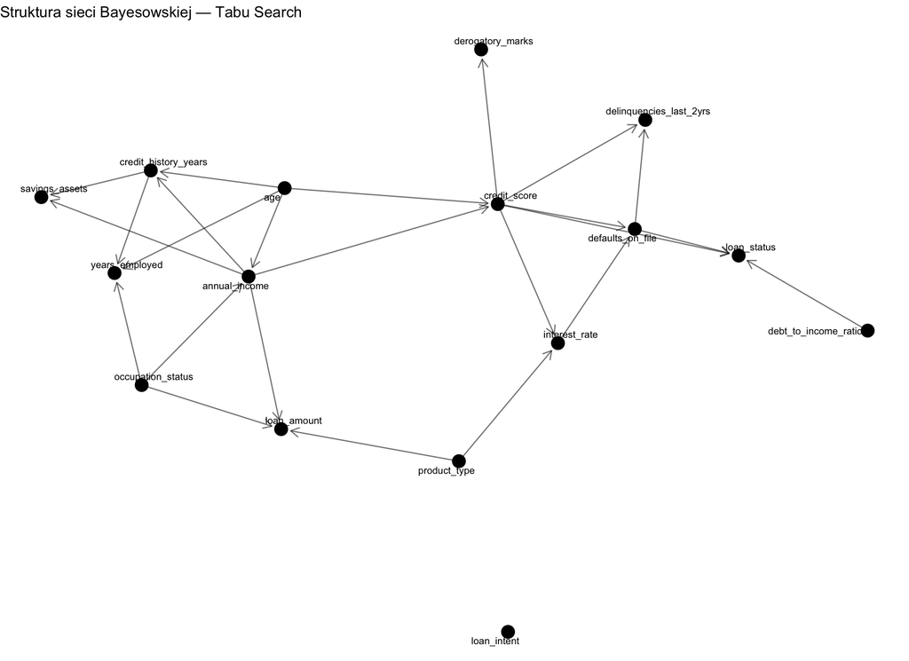

## 10.2 Bezpośrednie otoczenie `loan_status`

Bezpośredni rodzice zmiennej loan_status

| Zmienna_wynikowa | Rodzic |
| --- | --- |
| loan_status | credit_score |
| loan_status | defaults_on_file |
| loan_status | debt_to_income_ratio |

# 11 Uczenie parametrów

Po ustaleniu struktury przeprowadzono uczenie parametrów metodą bayesowską. Dla każdej zmiennej dyskretnej estymowane są warunkowe tabele prawdopodobieństwa (CPT).

```r
model_fit <- bnlearn::bn.fit(
  najlepszy_model,
  data = dane_bn,
  method = "bayes"
)
```

## 11.1 CPT dla `loan_status`

Warunkowa tabela prawdopodobieństw dla loan_status

| loan_status | credit_score | defaults_on_file | debt_to_income_ratio | Prawdopodobienstwo |
| --- | --- | --- | --- | --- |
| Odrzucona | niski | Nie | niski | 0.6646 |
| Pozytywna | niski | Nie | niski | 0.3354 |
| Odrzucona | sredni | Nie | niski | 0.2593 |
| Pozytywna | sredni | Nie | niski | 0.7407 |
| Odrzucona | wysoki | Nie | niski | 0.0597 |
| Pozytywna | wysoki | Nie | niski | 0.9403 |
| Odrzucona | niski | Tak | niski | 1.0000 |
| Pozytywna | niski | Tak | niski | 0.0000 |
| Odrzucona | sredni | Tak | niski | 0.9998 |
| Pozytywna | sredni | Tak | niski | 0.0002 |
| Odrzucona | wysoki | Tak | niski | 0.9998 |
| Pozytywna | wysoki | Tak | niski | 0.0002 |
| Odrzucona | niski | Nie | sredni | 0.6665 |
| Pozytywna | niski | Nie | sredni | 0.3335 |
| Odrzucona | sredni | Nie | sredni | 0.2448 |
| Pozytywna | sredni | Nie | sredni | 0.7552 |
| Odrzucona | wysoki | Nie | sredni | 0.0563 |
| Pozytywna | wysoki | Nie | sredni | 0.9437 |
| Odrzucona | niski | Tak | sredni | 1.0000 |
| Pozytywna | niski | Tak | sredni | 0.0000 |
| Odrzucona | sredni | Tak | sredni | 0.9997 |
| Pozytywna | sredni | Tak | sredni | 0.0003 |
| Odrzucona | wysoki | Tak | sredni | 0.9997 |
| Pozytywna | wysoki | Tak | sredni | 0.0003 |
| Odrzucona | niski | Nie | wysoki | 0.8840 |
| Pozytywna | niski | Nie | wysoki | 0.1160 |
| Odrzucona | sredni | Nie | wysoki | 0.6316 |
| Pozytywna | sredni | Nie | wysoki | 0.3684 |
| Odrzucona | wysoki | Nie | wysoki | 0.3885 |
| Pozytywna | wysoki | Nie | wysoki | 0.6115 |
| Odrzucona | niski | Tak | wysoki | 1.0000 |
| Pozytywna | niski | Tak | wysoki | 0.0000 |
| Odrzucona | sredni | Tak | wysoki | 0.9997 |
| Pozytywna | sredni | Tak | wysoki | 0.0003 |
| Odrzucona | wysoki | Tak | wysoki | 0.9997 |
| Pozytywna | wysoki | Tak | wysoki | 0.0003 |

## 11.2 Dodatkowa CPT dla zmiennej istotnej interpretacyjnie

Zamiast zakładać z góry, że konkretny węzeł jest rodzicem `loan_status`, zmienna do dodatkowej prezentacji CPT jest wybierana dynamicznie. Jeżeli `credit_score` jest bezpośrednim rodzicem decyzji, wykorzystywana jest ta zmienna; w przeciwnym razie pokazywany jest pierwszy dostępny rodzic `loan_status`.

Tabela prawdopodobieństw dla credit_score

| credit_score | age | annual_income | Prawdopodobienstwo |
| --- | --- | --- | --- |
| niski | niski | niski | 0.5188 |
| sredni | niski | niski | 0.3171 |
| wysoki | niski | niski | 0.1641 |
| niski | sredni | niski | 0.3565 |
| sredni | sredni | niski | 0.3535 |
| wysoki | sredni | niski | 0.2901 |
| niski | wysoki | niski | 0.2188 |
| sredni | wysoki | niski | 0.3417 |
| wysoki | wysoki | niski | 0.4395 |
| niski | niski | sredni | 0.4832 |
| sredni | niski | sredni | 0.3307 |
| wysoki | niski | sredni | 0.1862 |
| niski | sredni | sredni | 0.3381 |
| sredni | sredni | sredni | 0.3574 |
| wysoki | sredni | sredni | 0.3045 |
| niski | wysoki | sredni | 0.1893 |
| sredni | wysoki | sredni | 0.3397 |
| wysoki | wysoki | sredni | 0.4710 |
| niski | niski | wysoki | 0.4238 |
| sredni | niski | wysoki | 0.3523 |
| wysoki | niski | wysoki | 0.2239 |
| niski | sredni | wysoki | 0.2856 |
| sredni | sredni | wysoki | 0.3486 |
| wysoki | sredni | wysoki | 0.3658 |
| niski | wysoki | wysoki | 0.1559 |
| sredni | wysoki | wysoki | 0.2982 |
| wysoki | wysoki | wysoki | 0.5459 |

# 12 Wnioskowanie probabilistyczne

Przeprowadzono cztery scenariusze. Pierwszy pokazuje rozkład decyzji bez dodatkowej informacji. Kolejne pokazują, jak zmienia się rozkład `loan_status` po uwzględnieniu różnych zestawów informacji o kliencie.

Wyniki wnioskowania prognostycznego

| Scenariusz | Prawdopodobienstwo_odrzucenia | Prawdopodobienstwo_pozytywnej_decyzji |
| --- | --- | --- |
| Brak dodatkowych informacji | 0.4496 | 0.5504 |
| Wysoki credit score, brak defaultów, niski DTI | 0.0597 | 0.9403 |
| Średni credit score, brak defaultów, wysoki DTI | 0.6316 | 0.3684 |
| Default w historii | 0.9999 | 0.0001 |

## 12.1 Wnioskowanie diagnostyczne

Wnioskowanie diagnostyczne odwraca pytanie: zamiast pytać o decyzję przy znanych cechach klienta, zakładamy znany wynik i sprawdzamy prawdopodobieństwo określonego profilu.

Wynik wnioskowania diagnostycznego

| Pytanie | Prawdopodobienstwo |
| --- | --- |
| P(wysoki credit_score i niski DTI \| loan_status = Pozytywna) | 0.1846 |

## 12.2 Porównanie scenariuszy

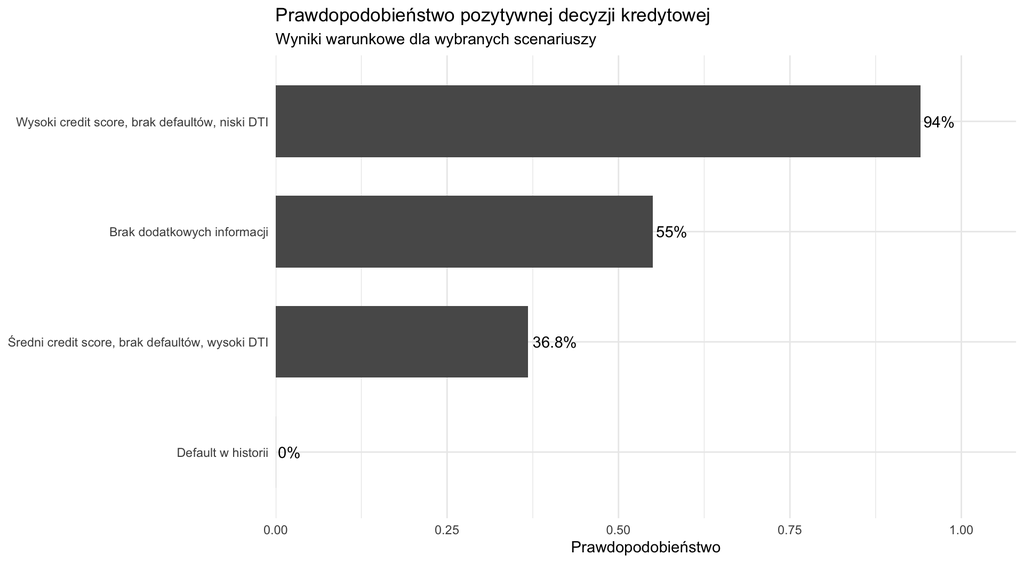

# 13 Interpretacja wyników

W scenariuszu bazowym model przypisuje pozytywnej decyzji prawdopodobieństwo **55%**. Po uwzględnieniu wysokiego `credit_score`, braku defaultów i niskiego DTI wartość ta wynosi **94%**, natomiast dla średniego `credit_score`, braku defaultów i wysokiego DTI wynosi **36.8%**.

Po ustawieniu `defaults_on_file = Tak` warunkowe prawdopodobieństwo pozytywnej decyzji wynosi **0%**. Wynik należy odczytywać razem z wcześniejszą analizą danych, w której dla tej grupy nie występowały pozytywne decyzje. Estymacja bayesowska może jednak przypisać zdarzeniom niewidzianym w próbie małe niezerowe prawdopodobieństwo.

Różnice między scenariuszami opisują **zmianę warunkowego rozkładu w nauczonej sieci**. Nie są oszacowaniem efektu przyczynowego. Stwierdzenia typu „zmiana DTI powoduje zmianę decyzji” byłyby na podstawie tego projektu zbyt silne; właściwa interpretacja dotyczy współwystępowania informacji i warunkowych prawdopodobieństw.

# 14 Interpretacja biznesowa

Z punktu widzenia analizy ryzyka sieć Bayesowska może wspierać:

- analizę scenariuszy dla różnych profili klientów,
- identyfikację zmiennych znajdujących się najbliżej `loan_status` w nauczonej strukturze,
- prezentację warunkowych prawdopodobieństw w bardziej przejrzystej formie niż pojedynczy wynik scoringowy,
- diagnostyczne pytania odwrotne, np. jakie profile klientów częściej występują w grupie pozytywnych decyzji.

Największą wartością projektu nie jest samo przewidywanie decyzji, lecz możliwość łączenia **struktury zależności** z **wnioskowaniem probabilistycznym**. W praktycznym środowisku bankowym taki model wymagałby jednak niezależnej walidacji, kontroli jakości danych, oceny zgodności regulacyjnej i monitoringu stabilności.

# 15 Ograniczenia

1. **Brak interpretacji przyczynowej.** Kierunki łuków są częściowo wynikiem algorytmu, a częściowo przyjętej blacklisty; nie stanowią dowodu przyczynowości.
2. **Dyskretyzacja traci informację.** Zamiana zmiennych ciągłych na kilka kategorii ułatwia budowę dyskretnej sieci, ale upraszcza dane.
3. **Walidacja nie obejmuje całego pipeline’u preprocessingowego.** Progi dyskretyzacji zostały ustalone przed 5-fold CV, więc wynik CV jest uzupełniającą oceną modelu, a nie produkcyjną estymacją jakości na całkowicie nowych danych.
4. **Silne wzorce specyficzne dla zbioru.** W danych `defaults_on_file = 1` nie współwystępuje z pozytywną decyzją. Taka zależność może silnie wpływać na strukturę i nie musi odzwierciedlać reguły rzeczywistego banku.
5. **Zmienne pochodne.** W źródłowym zbiorze występują prawie deterministyczne relacje między częścią wskaźników; dlatego część kolumn celowo usunięto.
6. **Stabilność struktury jest szacowana, a nie gwarantowana.** Bootstrap pokazuje częstość występowania łuków w próbach, ale nie rozwiązuje wszystkich problemów identyfikacji struktury.
7. **Projekt nie jest systemem scoringowym.** Nie analizowano kalibracji prawdopodobieństw, kosztów błędów decyzyjnych, fairness, driftu ani wymogów regulacyjnych wymaganych w zastosowaniu produkcyjnym.

# 16 Wnioski końcowe

W projekcie zbudowano dyskretną sieć Bayesowską do analizy decyzji kredytowych na zbiorze 50 000 obserwacji. Przed uczeniem struktury wykonano kontrolę jakości danych oraz przeanalizowano redundancję cech. Z modelu usunięto zmienne niemal deterministycznie powiązane z innymi kolumnami, aby ograniczyć ryzyko interpretowania relacji matematycznych jako niezależnych zależności między cechami.

Porównano algorytmy Hill-Climbing, Tabu Search i MMHC przy bardziej spójnych ograniczeniach strukturalnych. Do dalszej analizy wybrano **Tabu Search**. Wybrana struktura zawiera **16 węzłów** i **24 łuków**.

Uzupełniająca walidacja krzyżowa dla wybranego algorytmu dała trafność **77.3%**, przy trafności klasyfikatora większościowego wynoszącej **55%**. Wynik ten jest pomocniczą miarą jakości, a nie podstawą do traktowania sieci jako gotowego systemu decyzyjnego.

Analiza bootstrapowa pokazała, które łuki są stabilniejsze względem zmian próby. Dzięki temu interpretacja sieci nie opiera się wyłącznie na jednej strukturze wyuczonej z pełnego zbioru.

Wnioskowanie probabilistyczne pozwoliło następnie porównać scenariusze klientów oraz przeprowadzić pytanie diagnostyczne przy znanej pozytywnej decyzji. Wyniki należy interpretować jako warunkowe zależności występujące w analizowanym zbiorze, a nie jako efekty przyczynowe.

Całość pokazuje zastosowanie sieci Bayesowskiej nie tylko jako modelu graficznego, lecz jako narzędzia łączącego eksplorację danych, uczenie struktury, ocenę stabilności, walidację oraz wnioskowanie probabilistyczne.

# 17 Bibliografia

1. Scutari, M. — dokumentacja pakietu `bnlearn`, wykorzystywanego do uczenia struktury i parametrów sieci Bayesowskich.
2. Højsgaard, S. — dokumentacja pakietu `gRain`, wykorzystywanego do wnioskowania probabilistycznego w sieciach Bayesowskich.
3. R Core Team — dokumentacja środowiska R, wykorzystywanego do przygotowania danych, analizy i wizualizacji.
4. Wickham, H. i współautorzy — dokumentacja pakietów `dplyr` oraz `ggplot2`, wykorzystanych do transformacji danych i przygotowania wykresów.
5. Zbiór danych `Loan_approval_data_2025.csv`, wykorzystany jako źródło danych empirycznych w projekcie. Źródło: https://www.kaggle.com/datasets/parthpatel2130/realistic-loan-approval-dataset-us-and-canada.